# Reproducible Research: Peer Assessment 1

Jerry Currie

2015-02-13

## Contents

- Overview
- Load Libraries & Version Info
- Loading and preprocessing the data *
- What is mean total number of steps taken per day? *
- What is the average daily activity pattern? *
- Imputing missing values *
- Are there differences in activity patterns between weekdays and weekends? *

(note: asterisk * represents assignment requirement) ## Overview ######################################################## The objective of this project is to build a knitr document containing all the required information to reproduce an experiement. The experiment is to read in a set of data that’s missing about 15% of its values. Plots are made to illustate how similar plots appear, even if missing values are replaced with averages.

Questions are also answered about exercise times for a population counting steps taken each day. The raw data (activity.csv) can be found at: https://github.com/JCurrie2014/RepData_PeerAssessment1

## Load Libraries & Version Info

- OS: Windows 7 Home Premium
- R: Version 3.1.2
- Rstudio: Version 0.98.1091
- knitr: Version 1.9

```r
library(dplyr) # Version 0.40
library(lubridate) # Version 1.33
library(timeDate )# Version
```

## Loading and preprocessing the data *

The only data file (activity.csv) is read into a data frame named dfactivity. An identity field is added so that merging can be easily accomplished later in the project. A second data frame is created that excludes NAs that will be used for the first section of the assignment.

```r
echo = TRUE
#Read data file
dfactivity<-read.csv("activity.csv")
dfactivity$id<-1:nrow(dfactivity)    #Assign id to each row (will be used for imputing NA values)
dfactnaf<-na.omit(dfactivity) # remove NA and create data set for 1

# 1) #### Histogram without NAs in data set #########################
#Populate variables for histogram and averages
grp <- group_by(dfactnaf, date) #Group by date
sumsteps<-summarise(grp, sum=sum(steps)) #sum steps by day

#Calclate mean and median outputs
meanperday<-mean(sumsteps$sum)  #calculate mean steps per day
medianperday<-median(sumsteps$sum) #calculate median steps per day

# 2) ####  Average steps per 5-minute time interval #################
grp2<-group_by(dfactnaf,interval) #Group by interval
sumstepsinterval<-summarise(grp2, sum=sum(steps)) #average steps by interval
sumstepsinterval$avgstepperday<-sumstepsinterval$sum/nrow(sumsteps) # Calculate average

#build interval string for time by additing 10000 to each interval.
#this will allows taking the 2&3 values as hours and the 4&5 values
#as minutes without incurring an error from the earlier time intervals.
sumstepsinterval$K<-sumstepsinterval$interval+10000
#Get max avg step per day info
maxavgstepperday<-sumstepsinterval[which(sumstepsinterval[, 3] == max(sumstepsinterval$avgstepperday)), ]

#Calculate time of day from 5-minute interval
t<-as.POSIXlt("1970-01-01 00:00:00 PST") #initialize time
tmpmin<-substr(toString(maxavgstepperday$K),4,5)
tmphour<-substr(toString(maxavgstepperday$K),2,3)
t$min<-t$min + as.numeric(tmpmin)
t$hour<-t$hour+as.numeric(tmphour)
tcvt<-strftime(t, format = "%I:%M:%S %p")

# 3) ####  Imputing values for NAs #################################
#Get NA count from original data set
sumna<-sum(is.na(dfactivity$step))
#Create NA subset of dfactivity
dfisna<-dfactivity[is.na(dfactivity[,1])==T,]
#Join on sumstepsinterval$interval return
ajoin<-merge(dfisna, sumstepsinterval, by="interval")
#update NA steps with avg step per day for interval
ajoin$steps<-ajoin$avgstepperday
#Row bind dfactnaf with ajoin data frame to build completely filled
#version of the original data set (dfactivity)
tempactivity<-rbind(dfactnaf, ajoin[,c(1:4)])
newactivity<-arrange(tempactivity, id)

#Populate variables for histogram and averages
grp3 <- group_by(newactivity, date) #Group by date
sumsteps3<-summarise(grp3, sum=sum(steps)) #sum steps by day
#Calclate mean and median outputs
meanperday3<-mean(sumsteps3$sum)  #calculate mean steps per day
medianperday3<-median(sumsteps3$sum) #calculate median steps per day

# 4) ####  Create Weedend & Weekday plots ##########################
#Create field for identifying weekdays and weekend (weekday)
newactivity$weekday[isWeekday(newactivity$date) == T] <- "Weekday"
newactivity$weekday[isWeekday(newactivity$date) == F] <- "Weekend"
#create data frames separating weekday and weekends
dfweekend<-newactivity[which(newactivity[, 5] == "Weekend"), ]
dfweekday<-newactivity[which(newactivity[, 5] == "Weekday"), ]

#Create Weekend group
grp4<-group_by(dfweekend,interval) #Group by interval
wesumstepsinterval<-summarise(grp4, sum=sum(steps)) #average steps by interval
wesumstepsinterval$avgstepperdaywe<-wesumstepsinterval$sum/nrow(sumsteps)
#build interval string for time by additing 10000 to each interval.
#this will allows taking the 2&3 values as hours and the 4&5 values
#as minutes without incurring an error from the earlier time intervals.
wesumstepsinterval$K<-wesumstepsinterval$interval+10000
#Get max avg step per day info
maxavgstepperday3<-wesumstepsinterval[which(wesumstepsinterval[, 3] == max(wesumstepsinterval$avgstepperdaywe)), ]

#Create Weekday group
grp5<-group_by(dfweekday,interval) #Group by interval
wdsumstepsinterval<-summarise(grp5, sum=sum(steps)) #average steps by interval
wdsumstepsinterval$avgstepperdaywd<-wdsumstepsinterval$sum/nrow(sumsteps)
#build interval string for time by additing 10000 to each interval.
#this will allows taking the 2&3 values as hours and the 4&5 values
#as minutes without incurring an error from the earlier time intervals.
wdsumstepsinterval$K<-wdsumstepsinterval$interval+10000
#Get max avg step per day info
maxavgstepperday4<-wdsumstepsinterval[which(wdsumstepsinterval[, 3] == max(wdsumstepsinterval$avgstepperdaywd)), ]
```

## What is mean total number of steps taken per day? *

The histogram (below) shows number of steps per day grouped into clusters. The frequency represents the number of times data fell into each cluster.

- The average (mean) number of steps is **10,766.19** over 53 days.
- The median number of steps is **10,765** over 53 days.

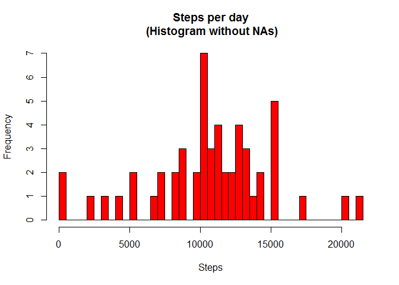

```r
# 1) Histogram without NAs in data set
#histogram of steps per day
hist(sumsteps$sum, main="Steps per day\n (Histogram without NAs)",ylab="Frequency", xlab="Steps", breaks=nrow(sumsteps), col="red")
```

## What is the average daily activity pattern?

There are 288 5-minute time intervals ranging from 0 to 2355. The x-axis corresponds to the specific interval break points found in the data set. NAs have been excluded from the computation.

- The time inteval ‘’835-840’’ contains the highest average number of steps at: **206.17** per day
- The most popular time of day for stepping is: **08:35:00 AM**.

(note: The data contains 12 5-minute groups per hour (0-55). After reaching the 12th member of the group (interval ending in 55), the interval’s hundred digit is incremented representing the current hour (i.e. The interval 100=1:00 am, 105=1:05 am … 2355 = 11:55 pm.))

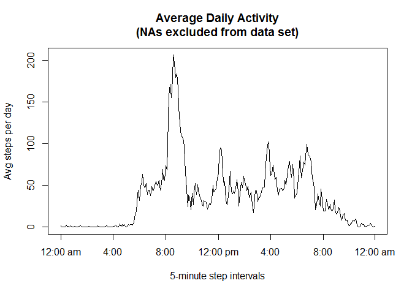

```r
# 2) ####  Average steps per 5-minute time interval #################
plot(sumstepsinterval$avgstepperday,type="l", xaxt="n",  xlab="5-minute step intervals", ylab="Avg steps per day", main="Average Daily Activity\n (NAs excluded from data set) ")
axis(1, at=c(1,49,97,145,193,241,288), labels=c("12:00 am","4:00","8:00","12:00 pm","4:00","8:00","12:00 am"))
```

## Imputing missing values

Here’s a Histogram containing average step values for all NAs in original data set.NA were replaced with the average (mean) steps per interval.

- There are **2304** missing values (NAs) in the main data set of **17568** records.
- The average (mean) number of steps is **10,766.19** over 61 days.
- The median number of steps is **10,766.19** over 61 days.

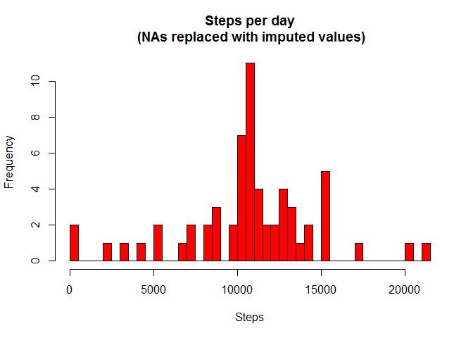

```r
# 3) ####  Imputing values for NAs #################################
#histogram of steps per day using imputed values
hist(sumsteps3$sum, main="Steps per day\n (NAs replaced with imputed values)",ylab="Frequency" , xlab="Steps", breaks=nrow(sumsteps3), col="red")
```

## Are there differences in activity patterns between weekdays and weekends?

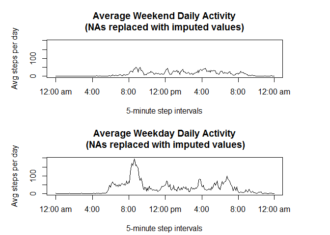

```r
##################  Plot 4 Charts ###########################################
# 4) ####  Create Weedend & Weekday plots ##########################
par(mfrow=c(2,1))
par(pin=c(5,.8))
#First plot Weekend scaled to maximum weekday
plot(wesumstepsinterval$avgstepperdaywe,type="l", ylim=c(0,max(wdsumstepsinterval$avgstepperdaywd)), xaxt="n",  xlab="5-minute step intervals", ylab="Avg steps per day", main="Average Weekend Daily Activity\n (NAs replaced with imputed values) ")
axis(1, at=c(1,49,97,145,193,241,288), labels=c("12:00 am","4:00","8:00","12:00 pm","4:00","8:00","12:00 am"))
#Second plot weekday
plot(wdsumstepsinterval$avgstepperdaywd,type="l", xaxt="n",  xlab="5-minute step intervals", ylab="Avg steps per day", main="Average Weekday Daily Activity\n (NAs replaced with imputed values)")
axis(1, at=c(1,49,97,145,193,241,288), labels=c("12:00 am","4:00","8:00","12:00 pm","4:00","8:00","12:00 am"))
```